# A Quick Performance Anlysis of Adaptive Metropolis

Ye (Eric) Wang

2/21/2017

Go back to Ye Wang’s homepage http://ericyewang.github.io

Metropolis (Hasting) algorithm could suffer terrible mixing issue, i.e., slow convergence to the stationary and strong auto-correlation, if the target distribution is multi-dimensional and has complex correlation structure. This difficulty could be mitigated if the proposal distribution is carefully chosen to be close to the target distribution. To understand why a carefully chosen proposal would help, imagine the following extreme case: say the proposal distribution is exactly the same as the target distribution, then the proposed sample will always be accepted with probability one and the samples are immediately i.i.d. samples from the target distribution. There is no time needed to converge and the auto-correlation will be zero. Intuitively, the closer the proposal is to the target, the less effort the algorithm needs to make in order to mix well.

But the target is usually intractable and the proposal is usally selected so that it is easy to sample from (e.g., a Gaussian). A nutural idea is to use this Gaussian to approximate the target distribution. Doing this gives us the **adaptive Metropolis** algorithm (Haario et al., 2001). For more details, see the original paper https://projecteuclid.org/euclid.bj/1080222083. Roughly speaking, the **adaptive Metropolis** algorithm (AM) adapts the covariance matrix of the proposal distribution using all the past samples.

To be more specific, let x1,x2,…,xt be the t previous samples at time t+1, Haario et al. (2001) proposed to use a Gaussian distribution centered at xt as the proposal distribution. The covariance matrix of this proposal distribution is calculated as

`sd` cov(x1,…,xt)+ `sd` `eps` diag(1,…,1).

To convince myself about the performance of AM, I decided to do the following small experiment and compare its performance with standard Metropolis on sampling from a highly correlated multivariate Gaussian target.

## Create a Target Distribution

I used the AM algorithm to sample from a 10-dimensional centered Gaussian distribution and I used the following code to create a covariance matrix for this distribution. As can be seen, the covariance matrix is created in a way such that there tends to be a complicated correlation structure hence the standanrd metropolis (hastings) algorithm might suffer.

```r
suppressMessages(require(mvtnorm))
p = 10 # dimension
Fc = matrix(rnorm(p*p),p,p) # loadings for the covariance matrix
C = Fc%*%t(Fc)+diag(0.1,p) # create a covariance matrix
ldens <- function(x,C){
  # log density function of the target distribution
  # up to a normalizing constant
  return(-t(x)%*%solve(C)%*%x)
}
```

## AM Sampling

I wrote an R function for AM myself and it can be found in https://github.com/ericyewang/adaptive_metropolis. Note that `sd` and `eps` are the tuning parameters and I fixed them at values recommended by Haario et al., 2001.

```r
source("https://raw.githubusercontent.com/ericyewang/adaptive_metropolis/master/am_fcn.R")

t0 = 200
t1 = t0+200
nm = 5000
sBeta = adaptiveMetropolis(p=p,t0=t0,t1=t1,nm=nm,sd_mh=0.1,ldens=ldens,C=C)
```

```
## iteration 500
## iteration 1000
## iteration 1500
## iteration 2000
## iteration 2500
## iteration 3000
## iteration 3500
## iteration 4000
## iteration 4500
## iteration 5000
```

## Standard Metropolis Algorithm

In order to demonstrate the performance of AM, I also did the following standard Metropolis algorithm.

```r
nm = 5000
sBeta0 = NULL
beta = rep(0,p)
for (iter in 1:nm){
  # propose new beta
  nbeta = beta + 0.5*rnorm(10)
  lalpha = dmvnorm(nbeta,rep(0,p),C,log=TRUE)-dmvnorm(beta,rep(0,p),C,log=TRUE)
  if (log(runif(1))<lalpha){
    beta = nbeta
  }
  # store the samples
  sBeta0 = cbind(sBeta0,beta)
}
```

## Comparison

To demonstrate the performance of AM, I compare the traceplots of AM with the traceplots of standard Metropolis:

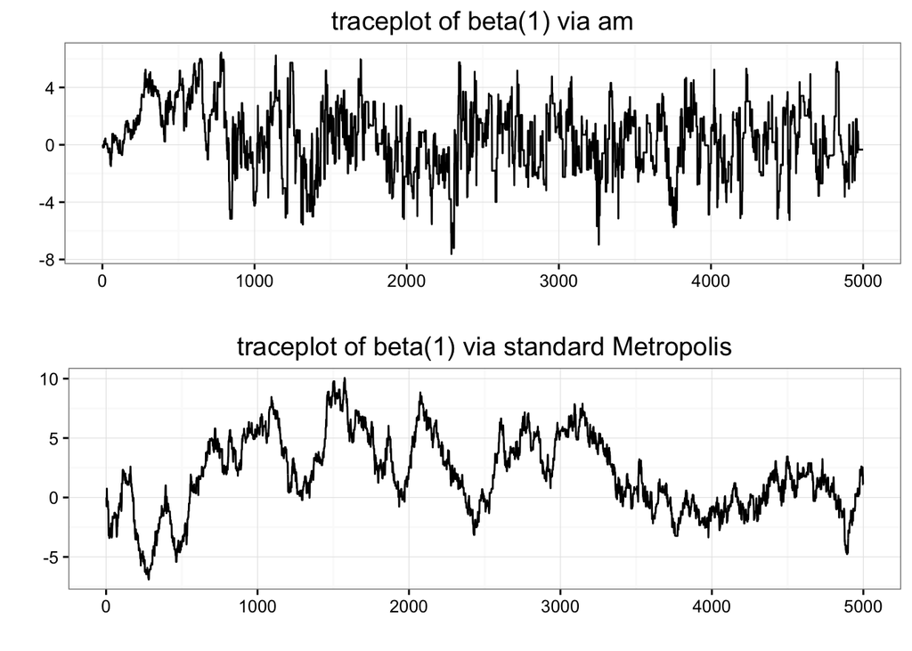

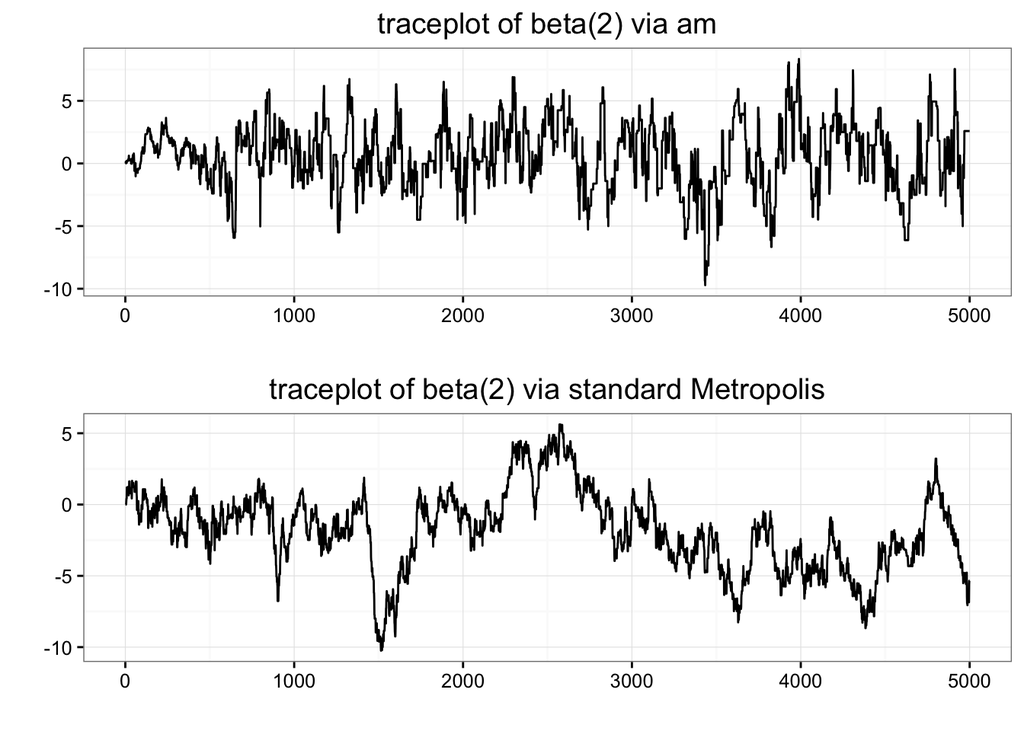

As can be clearly seen, the mixing of AM is much better than that of the standard Metropolis. Note that the performance of the standard Metropolis could be improved by tuning the standanrd deviation parameter of the proposal. But AM is almost tuning-free. One downside of the current version of AM is that it can only sample from continuous target function due to the usage of a Gaussian proposal.